# Us tuition

Mohsen

31/03/2021

```r
colleges.colnames <- c(
    "FID",
    "names",
    "zip",
    "Private",
    "Math",
    "verbal",
    "combined",
    "average.ACT",
    "1stqmath",
    "3rdqmath",
    "1stqverbal",
    "3rdqverbal",
    "1stqACT",
    "3rdqACT",
    "Apps",
    "Accept",
    "Enroll",
    "Top10perc",
    "Top25perc",
    "F.Undergrad",
    "P.Undergrad",
    "instate",
    "Outstate",
    "Room.Board",
    "room",
    "board",
    "add.cost",
    "Books",
    "Personal",
    "PhD",
    "Terminal",
    "S.F.Ratio",
    "perc.alumni",
    "Expend",
    "Grad.Rate"
)
colleges <- read_csv("usnews.data", col_names = colleges.colnames, na="*")
profs.colnames <- c(
    "FID",
    "names",
    "zip",
    "type",
    "ave.salary.prf",
    "ave.salary.acprf",
    "ave.salary.asprf",
    "ave.salary.allprf",
    "ave.comp.prf",
    "ave.comp.acprf",
    "ave.comp.asprf",
    "ave.comp.allprf",
    "no.prf",
    "no.acprf",
    "no.asprf",
    "no.inprf",
    "no.allprf"
)
profs <- read_csv("aaup.data",col_names = profs.colnames, na = "*")
colleges %>% summarize(distinct = n_distinct(names)) %>% pull()
```

```
## [1] 1274
```

We have 1302 rows but 1274 universities?

```r
colleges %>% summarize(distinct = n_distinct(FID)) %>% pull()
```

```
## [1] 1302
```

But Federal IDs are 1302?

```r
colleges[which(duplicated(colleges[,2])==TRUE),]
```

| FID | names | zip | Private | Math | verbal | combined | average.ACT | 1stqmath | 3rdqmath | 1stqverbal | 3rdqverbal | 1stqACT | 3rdqACT | Apps | Accept | Enroll | Top10perc | Top25perc | F.Undergrad | P.Undergrad | instate | Outstate | Room.Board | room | board | add.cost | Books | Personal | PhD | … |
| --- | --- | --- | --- | --- | --- | --- | --- | --- | --- | --- | --- | --- | --- | --- | --- | --- | --- | --- | --- | --- | --- | --- | --- | --- | --- | --- | --- | --- | --- | --- |
| 1460 | Trinity College | DC | 2 | 470 | 480 | 950 | 22 | 410 | 510 | 420 | 550 | 18 | 25 | 247 | 189 | 100 | 19 | 49 | 309 | 639 | 11412 | 11412 | 6430 | 2900 | 3530 | 150 | 500 | 900 | 89 | … |
| 1666 | Concordia University | IL | 2 | NA | NA | NA | 23 | NA | NA | NA | NA | 20 | 26 | 528 | 403 | 186 | 22 | 56 | 1168 | 145 | 9216 | 9216 | 4191 | 4191 | NA | 80 | 400 | 1000 | 56 | … |
| 1700 | Judson College | IL | 2 | NA | NA | NA | 22 | NA | NA | NA | NA | 19 | 24 | 313 | 228 | 137 | 10 | 30 | 552 | 67 | 9414 | 9414 | 4554 | NA | NA | 400 | 500 | 1700 | 34 | … |
| 1772 | Trinity College | IL | 2 | NA | NA | NA | NA | NA | NA | NA | NA | NA | NA | 746 | 473 | 317 | 39 | 82 | 834 | 50 | 9600 | 9600 | 4110 | 2030 | 2080 | 75 | 600 | 1300 | 54 | … |
| 1905 | Bethel College | KS | 2 | NA | NA | NA | 22 | NA | NA | NA | NA | 19 | 26 | 202 | 184 | 122 | 19 | 42 | 537 | 101 | 8540 | 8540 | 3580 | 1960 | 1620 | 200 | 500 | 1400 | 61 | … |
| 2227 | Wheaton College | MA | 2 | 550 | 530 | 1080 | 24 | 500 | 600 | 490 | 580 | 22 | 27 | 1738 | 1373 | 417 | 21 | 55 | 1335 | 30 | 18460 | 18460 | 5970 | 2900 | 3070 | 120 | 700 | 850 | 92 | … |
| 2051 | Saint Joseph's College | ME | 2 | 460 | 420 | 880 | NA | 390 | 510 | 370 | 470 | NA | NA | 833 | 682 | 217 | 12 | 33 | 716 | 2196 | 9985 | 9985 | 5180 | NA | NA | 295 | 500 | 800 | 53 | … |
| 2371 | Northwestern College | MN | 2 | 488 | 456 | 944 | 22 | 410 | 590 | 420 | 530 | 19 | 25 | 699 | 601 | 352 | 17 | 43 | 1209 | 33 | 11328 | 11328 | 3003 | 1095 | 1908 | NA | 400 | 1885 | 45 | … |
| 9058 | Bethel College | MN | 2 | NA | NA | NA | NA | NA | NA | NA | NA | NA | NA | 856 | 698 | 310 | NA | NA | 1617 | 102 | 11050 | 11050 | 4000 | 1780 | 2220 | NA | NA | NA | 60 | … |
| 2456 | Columbia College | MO | 2 | NA | NA | NA | 20 | NA | NA | NA | NA | NA | NA | 314 | 158 | 132 | 10 | 28 | 690 | 5346 | 8294 | 8294 | 3700 | 1372 | 2328 | 45 | 400 | 900 | 87 | … |

[output cut: 18 more lines]

The similar universities’ name are in the different states.

```r
summary(colleges)
```

```
##       FID           names               zip               Private
##  Min.   : 1002   Length:1302        Length:1302        Min.   :1.000
##  1st Qu.: 1874   Class :character   Class :character   1st Qu.:1.000
##  Median : 2650   Mode  :character   Mode  :character   Median :2.000
##  Mean   : 3126                                         Mean   :1.639
##  3rd Qu.: 3431                                         3rd Qu.:2.000
##  Max.   :30431                                         Max.   :2.000
##
##       Math           verbal         combined       average.ACT
##  Min.   :320.0   Min.   :280.0   Min.   : 600.0   Min.   :11.00
##  1st Qu.:460.0   1st Qu.:422.0   1st Qu.: 884.5   1st Qu.:20.25
##  Median :500.0   Median :457.0   Median : 957.0   Median :22.00
##  Mean   :506.8   Mean   :461.2   Mean   : 968.0   Mean   :22.12
##  3rd Qu.:544.0   3rd Qu.:492.0   3rd Qu.:1038.0   3rd Qu.:24.00
##  Max.   :750.0   Max.   :665.0   Max.   :1410.0   Max.   :31.00
##  NA's   :525     NA's   :525     NA's   :523      NA's   :588
##     1stqmath        3rdqmath       1stqverbal      3rdqverbal
##  Min.   :220.0   Min.   :330.0   Min.   :200.0   Min.   :330.0
##  1st Qu.:410.0   1st Qu.:530.0   1st Qu.:380.0   1st Qu.:480.0
##  Median :453.0   Median :580.0   Median :410.0   Median :530.0
##  Mean   :462.2   Mean   :583.1   Mean   :418.5   Mean   :530.5
##  3rd Qu.:510.0   3rd Qu.:630.0   3rd Qu.:450.0   3rd Qu.:570.0
##  Max.   :740.0   Max.   :785.0   Max.   :630.0   Max.   :720.0
##  NA's   :530     NA's   :530     NA's   :530     NA's   :530
##     1stqACT         3rdqACT           Apps             Accept
##  Min.   :10.00   Min.   :15.00   Min.   :   35.0   Min.   :   35.0
##  1st Qu.:18.00   1st Qu.:23.00   1st Qu.:  695.8   1st Qu.:  554.5
##  Median :19.00   Median :25.00   Median : 1470.0   Median : 1095.0
##  Mean   :19.82   Mean   :25.11   Mean   : 2752.1   Mean   : 1870.7
##  3rd Qu.:22.00   3rd Qu.:27.00   3rd Qu.: 3314.2   3rd Qu.: 2303.0
##  Max.   :29.00   Max.   :35.00   Max.   :48094.0   Max.   :26330.0
##  NA's   :639     NA's   :639     NA's   :10        NA's   :11
##      Enroll         Top10perc       Top25perc       F.Undergrad
##  Min.   :  18.0   Min.   : 1.00   Min.   :  6.00   Min.   :   59
##  1st Qu.: 236.0   1st Qu.:13.00   1st Qu.: 36.75   1st Qu.:  966
##  Median : 447.0   Median :21.00   Median : 50.00   Median : 1812
##  Mean   : 778.9   Mean   :25.67   Mean   : 52.35   Mean   : 3693
##  3rd Qu.: 984.0   3rd Qu.:32.00   3rd Qu.: 66.00   3rd Qu.: 4540
##  Max.   :7425.0   Max.   :98.00   Max.   :100.00   Max.   :31643
##  NA's   :5        NA's   :235     NA's   :202      NA's   :3
```

[output cut: 17 more lines]

```
##  Min.   :  8.00   Min.   : 20.00   Min.   : 2.30   Min.   : 0.00
##  1st Qu.: 57.00   1st Qu.: 63.00   1st Qu.:11.80   1st Qu.:11.00
##  Median : 71.00   Median : 77.00   Median :14.30   Median :19.00
##  Mean   : 68.65   Mean   : 75.23   Mean   :14.86   Mean   :20.91
##  3rd Qu.: 82.00   3rd Qu.: 90.00   3rd Qu.:17.60   3rd Qu.:29.00
##  Max.   :105.00   Max.   :100.00   Max.   :91.80   Max.   :81.00
##  NA's   :32       NA's   :30       NA's   :2       NA's   :222
##      Expend        Grad.Rate
##  Min.   : 1834   Min.   :  8.00
##  1st Qu.: 6116   1st Qu.: 47.00
##  Median : 7729   Median : 60.00
##  Mean   : 8988   Mean   : 60.41
##  3rd Qu.:10054   3rd Qu.: 74.00
##  Max.   :62469   Max.   :118.00
##  NA's   :39      NA's   :98
```

The math, verbal, ACT’s scores have a lot of NA, i.e. about more than 500 out of 1302, so we cannot take these variables into account.

Also, Room expense and board expense have a lot of NAs, but column which is represent summation of these two variables only has 76 NAs.

We decided to predict out of state tuition, so we omit 20 NAs in this variables.

```r
colleges <- colleges[!is.na(colleges$Outstate),]
colleges$Elite <- factor(ifelse(colleges$Top10perc <= 50, "No", "Yes"))
colleges$enrollper <- 100*colleges$Enroll/colleges$Accept
colleges$acceptper <- 100*colleges$Accept/colleges$Apps
colleges$fulltimeper <- 100*colleges$F.Undergrad/(colleges$F.Undergrad + colleges$P.Undergrad)
colleges <- colleges[,-c(5:17,20:21,25,26)]
```

We add 4 new variables by using currents variables: 1-Elite : if 50% or more of students of a university came from top high schools,we name this university as ELite, universities with high reputation attract better students and tuition can be higher. 2- Enroll rate: what percentages of students who were admitted enroll in university?

3- accept rate: what percentages of applicants are admitted?

4- Full time student rate: what percentages of students are full-time?

```r
summary(profs)
```

```
##       FID           names               zip                type
##  Min.   : 1002   Length:1161        Length:1161        Length:1161
##  1st Qu.: 1903   Class :character   Class :character   Class :character
##  Median : 2668   Mode  :character   Mode  :character   Mode  :character
##  Mean   : 3052
##  3rd Qu.: 3420
##  Max.   :29269
##
##  ave.salary.prf   ave.salary.acprf ave.salary.asprf ave.salary.allprf
##  Min.   : 270.0   Min.   :234.0    Min.   :199.0    Min.   :232.0
##  1st Qu.: 440.0   1st Qu.:367.0    1st Qu.:313.0    1st Qu.:352.0
##  Median : 506.0   Median :413.0    Median :349.0    Median :407.0
##  Mean   : 524.1   Mean   :416.4    Mean   :351.9    Mean   :420.4
##  3rd Qu.: 600.0   3rd Qu.:461.0    3rd Qu.:388.0    3rd Qu.:475.0
##  Max.   :1009.0   Max.   :733.0    Max.   :576.0    Max.   :866.0
##  NA's   :68       NA's   :36       NA's   :24
##   ave.comp.prf    ave.comp.acprf  ave.comp.asprf  ave.comp.allprf
##  Min.   : 319.0   Min.   :292.0   Min.   :246.0   Min.   : 265.0
##  1st Qu.: 547.0   1st Qu.:456.0   1st Qu.:389.0   1st Qu.: 436.0
##  Median : 635.0   Median :519.0   Median :437.0   Median : 510.0
##  Mean   : 653.5   Mean   :523.8   Mean   :442.1   Mean   : 526.7
##  3rd Qu.: 753.0   3rd Qu.:583.0   3rd Qu.:493.0   3rd Qu.: 600.0
##  Max.   :1236.0   Max.   :909.0   Max.   :717.0   Max.   :1075.0
##  NA's   :68       NA's   :36      NA's   :24
##      no.prf         no.acprf         no.asprf         no.inprf
##  Min.   :  0.0   Min.   :  0.00   Min.   :  0.00   Min.   :  0.00
##  1st Qu.: 18.0   1st Qu.: 19.00   1st Qu.: 21.00   1st Qu.:  2.00
##  Median : 40.0   Median : 38.00   Median : 40.00   Median :  6.00
##  Mean   : 95.1   Mean   : 72.39   Mean   : 68.63   Mean   : 12.74
##  3rd Qu.:105.0   3rd Qu.: 89.00   3rd Qu.: 92.00   3rd Qu.: 14.00
##  Max.   :997.0   Max.   :721.00   Max.   :510.00   Max.   :178.00
##
##    no.allprf
##  Min.   :   7.0
##  1st Qu.:  68.0
##  Median : 132.0
##  Mean   : 257.4
##  3rd Qu.: 323.0
##  Max.   :2261.0
##
```

The number of NAs is acceptable. we go further with this data, and according to the out of state tuition, the salaries of professors based on the ranking is not important, so we the summation of all professors’ salary and compensation to one column. On the contrary, number of full professor compared to number of instructor is an important factor to compare universities. therefore, we can use these separated columns or one weighted summation column. Initially, we use separated columns.

```r
profs$allsalary=profs$ave.salary.allprf+profs$ave.comp.allprf
profs=profs[,-c(2:12,17)]
```

By using the left-join, we have one data frame now.

```r
colleges %>% left_join(profs, by=c("FID")) -> df
```

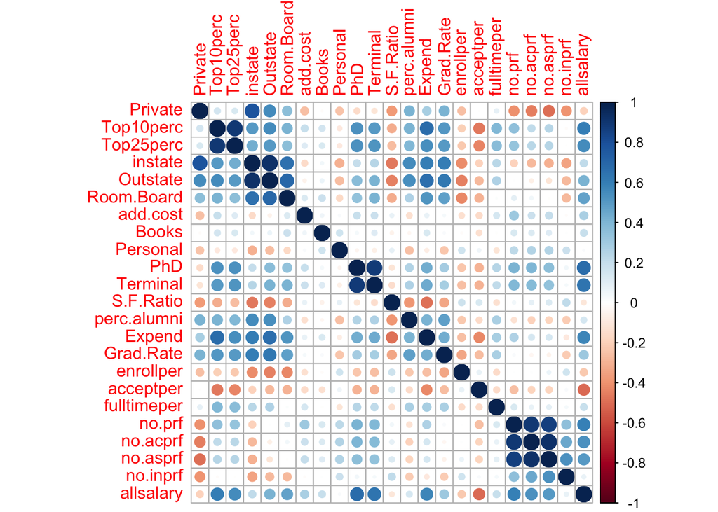

```r
library(corrplot)
correlation <- cor(df[c(4:18,20:27)], use="pairwise.complete.obs")
corrplot(correlation)
```

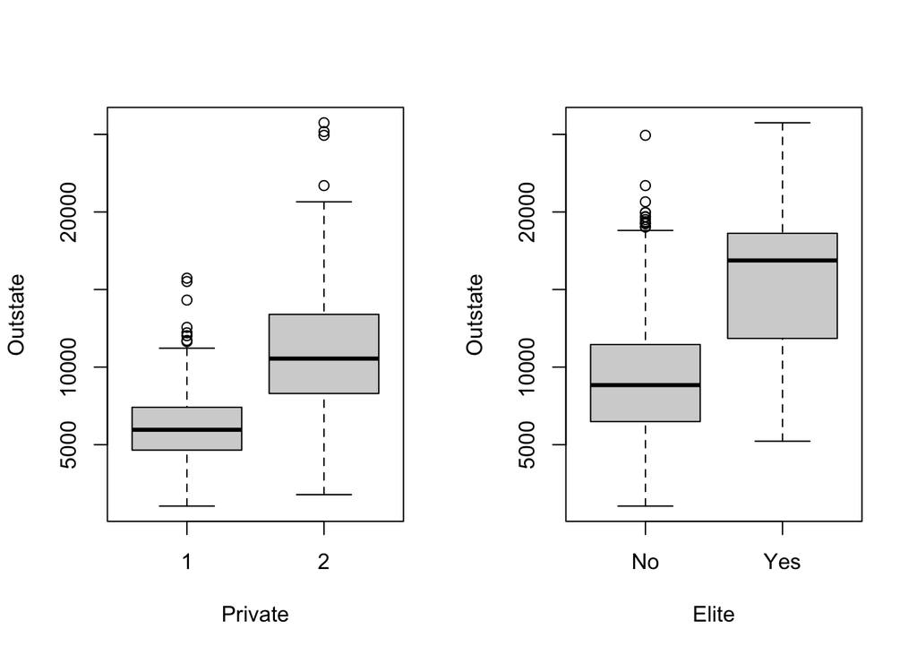

```r
par(mfrow=c(1,2))
plot(as.factor(df$Private),df$Outstate,xlab="Private",ylab="Outstate")
plot(df$Elite,df$Outstate,xlab="Elite",ylab="Outstate")
```

(public=1, private=2) public universities has lower out-state tuition. Non-elite universities has lower out-state tuition too.

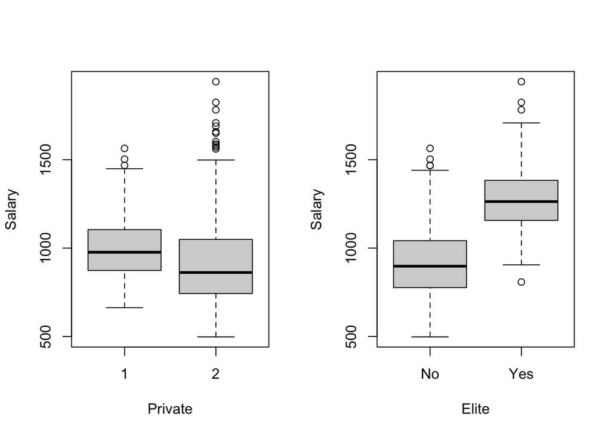

```r
par(mfrow=c(1,2))
plot(as.factor(df$Private),df$allsalary,xlab="Private",ylab="Salary")
plot(df$Elite,df$allsalary,xlab="Elite",ylab="Salary")
```

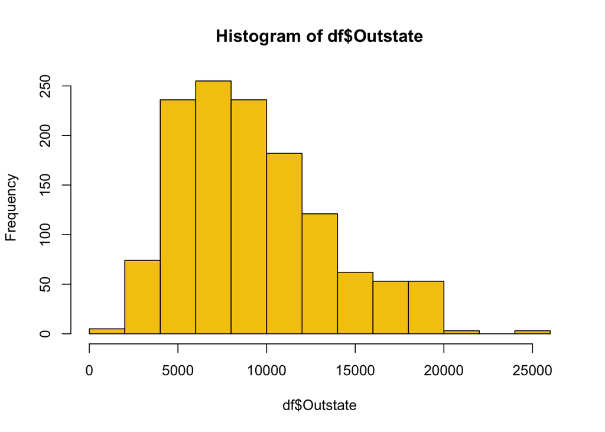

```r
hist(df$Outstate, col=23)
```

```r
df2 <- df
df2 = na.omit(df2)
```

(I deleted all NAs, but we need to impute true values)

test- train splite

```r
set.seed(1234)
df2 = df2[-c(1:3)]
df2$Private = as.factor(df2$Private)
College.train <- df2%>%sample_frac(0.70)
train_index <- as.numeric(rownames(College.train))
College.test <- df2[-train_index, ]
```

```r
library(leaps)
lm.subset.fit = regsubsets(Outstate~., data = df2)
reg.summary = summary(lm.subset.fit)
reg.summary
```

```
## Subset selection object
## Call: regsubsets.formula(Outstate ~ ., data = df2)
## 23 Variables  (and intercept)
##             Forced in Forced out
## Private2        FALSE      FALSE
## Top10perc       FALSE      FALSE
## Top25perc       FALSE      FALSE
## instate         FALSE      FALSE
## Room.Board      FALSE      FALSE
## add.cost        FALSE      FALSE
## Books           FALSE      FALSE
## Personal        FALSE      FALSE
## PhD             FALSE      FALSE
## Terminal        FALSE      FALSE
## S.F.Ratio       FALSE      FALSE
## perc.alumni     FALSE      FALSE
## Expend          FALSE      FALSE
## Grad.Rate       FALSE      FALSE
## EliteYes        FALSE      FALSE
## enrollper       FALSE      FALSE
## acceptper       FALSE      FALSE
## fulltimeper     FALSE      FALSE
## no.prf          FALSE      FALSE
## no.acprf        FALSE      FALSE
## no.asprf        FALSE      FALSE
## no.inprf        FALSE      FALSE
## allsalary       FALSE      FALSE
## 1 subsets of each size up to 8
## Selection Algorithm: exhaustive
##          Private2 Top10perc Top25perc instate Room.Board add.cost Books
## 1  ( 1 ) " "      " "       " "       "*"     " "        " "      " "
## 2  ( 1 ) "*"      " "       " "       "*"     " "        " "      " "
## 3  ( 1 ) "*"      " "       " "       "*"     " "        " "      " "
## 4  ( 1 ) "*"      " "       " "       "*"     " "        " "      " "
## 5  ( 1 ) "*"      " "       " "       "*"     " "        "*"      " "
## 6  ( 1 ) "*"      " "       " "       "*"     " "        "*"      " "
## 7  ( 1 ) "*"      " "       " "       "*"     " "        "*"      " "
## 8  ( 1 ) "*"      " "       " "       "*"     " "        "*"      " "
##          Personal PhD Terminal S.F.Ratio perc.alumni Expend Grad.Rate EliteYes
## 1  ( 1 ) " "      " " " "      " "       " "         " "    " "       " "
```

[output cut: 10 more lines]

```
## 3  ( 1 ) " "       " "       " "         " "    "*"      " "      " "
## 4  ( 1 ) "*"       " "       " "         " "    "*"      " "      " "
## 5  ( 1 ) "*"       " "       " "         " "    "*"      " "      " "
## 6  ( 1 ) "*"       " "       " "         " "    "*"      " "      " "
## 7  ( 1 ) "*"       " "       " "         " "    "*"      " "      " "
## 8  ( 1 ) "*"       " "       " "         " "    "*"      " "      "*"
##          allsalary
## 1  ( 1 ) " "
## 2  ( 1 ) " "
## 3  ( 1 ) " "
## 4  ( 1 ) " "
## 5  ( 1 ) " "
## 6  ( 1 ) " "
## 7  ( 1 ) " "
## 8  ( 1 ) " "
```

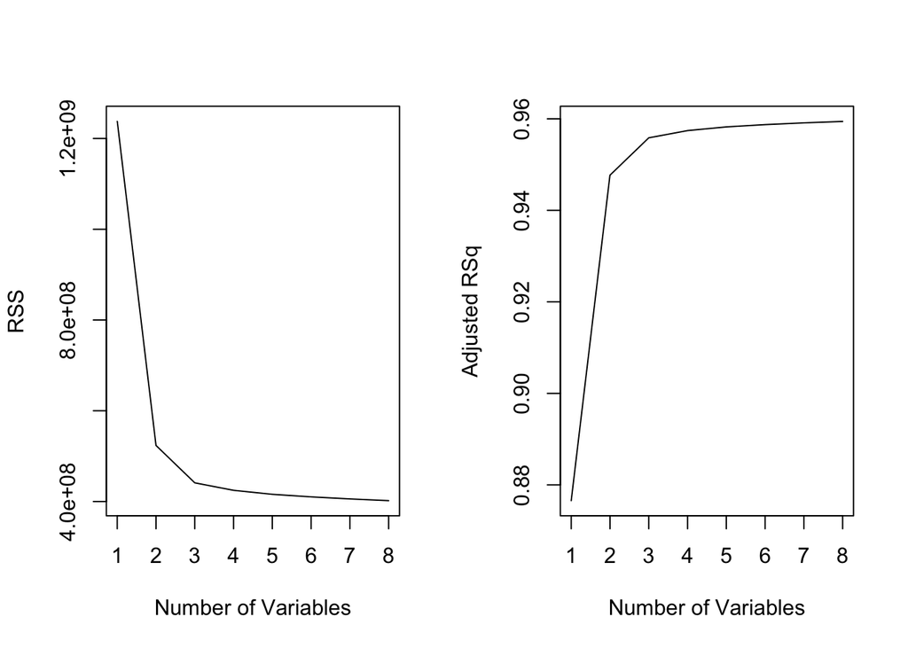

```r
par(mfrow=c(1,2))
plot(reg.summary$rss,xlab="Number of Variables",ylab="RSS",type="l")
plot(reg.summary$adjr2,xlab="Number of Variables",ylab="Adjusted RSq",type="l")
```

```r
which.max(reg.summary$adjr2)
```

```
## [1] 8
```

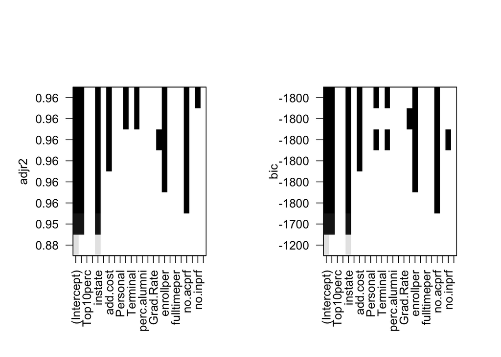

```r
par(mfrow=c(1,2))
plot(lm.subset.fit, scale="adjr2")
plot(lm.subset.fit, scale="bic")
```

```r
####### Step() function for forward, backward, and hybrid #####

result.null <- lm(Outstate~1, data=df2)
result.full <- lm(Outstate~., data=df2)


step(result.null,scope=list(upper=result.full), data=df2, direction="both")
```

```
## Start:  AIC=9778.56
## Outstate ~ 1
##
##               Df  Sum of Sq        RSS    AIC
## + instate      1 8805451757 1.2376e+09 8551.6
## + Expend       1 5040052884 5.0030e+09 9371.5
## + Room.Board   1 4309025833 5.7340e+09 9451.6
## + Top10perc    1 3702157618 6.3409e+09 9510.6
## + Private      1 3629296507 6.4138e+09 9517.3
## + Grad.Rate    1 3507837981 6.5352e+09 9528.3
## + perc.alumni  1 3377171702 6.6659e+09 9540.0
## + S.F.Ratio    1 3372010649 6.6711e+09 9540.4
## + Top25perc    1 2922307644 7.1208e+09 9578.7
## + enrollper    1 2004158060 8.0389e+09 9649.9
## + allsalary    1 1983279441 8.0598e+09 9651.4
## + Terminal     1 1872366478 8.1707e+09 9659.4
## + Elite        1 1819513875 8.2236e+09 9663.2
## + PhD          1 1802059837 8.2410e+09 9664.5
## + Personal     1  942777752 9.1003e+09 9722.7
## + acceptper    1  827771662 9.2153e+09 9730.1
## + fulltimeper  1  745257430 9.2978e+09 9735.3
## + no.inprf     1  487846862 9.5552e+09 9751.3
## + no.asprf     1  138085095 9.9050e+09 9772.4
## + no.acprf     1  127500384 9.9156e+09 9773.1
## + add.cost     1   84046267 9.9590e+09 9775.6
## <none>                      1.0043e+10 9778.6
## + Books        1   26652364 1.0016e+10 9779.0
## + no.prf       1    6964762 1.0036e+10 9780.2
##
## Step:  AIC=8551.56
## Outstate ~ instate
##
##               Df  Sum of Sq        RSS    AIC
## + Private      1  714039964 5.2358e+08 8048.6
## + allsalary    1  488510910 7.4911e+08 8258.8
## + no.acprf     1  412600724 8.2502e+08 8315.5
## + no.prf       1  383142403 8.5448e+08 8336.1
## + PhD          1  370612193 8.6701e+08 8344.6
## + no.asprf     1  361446363 8.7617e+08 8350.8
## + Terminal     1  336772603 9.0085e+08 8367.1
```

[output cut: 298 more lines]

```
## + Top10perc    1      26383  394716102 7902.7
## + Expend       1      13504  394728981 7902.8
## + Books        1       8638  394733847 7902.8
## + Top25perc    1       1523  394740962 7902.8
## + Room.Board   1          1  394742484 7902.8
## - allsalary    1    3111849  397854334 7903.4
## - S.F.Ratio    1    3382048  398124533 7903.8
## - Elite        1    3833503  398575987 7904.5
## - no.inprf     1    4149344  398891829 7904.9
## - PhD          1    4621593  399364077 7905.6
## - add.cost     1    6402414  401144899 7908.2
## - enrollper    1   14091926  408834411 7919.4
## - no.acprf     1   50235156  444977640 7969.1
## - Private      1  230587677  625330161 8168.8
## - instate      1 2012926933 2407669418 8960.2
```

```
##
## Call:
## lm(formula = Outstate ~ instate + Private + no.acprf + enrollper +
##     add.cost + Elite + no.inprf + S.F.Ratio + PhD + allsalary +
##     Grad.Rate, data = df2)
##
## Coefficients:
## (Intercept)      instate     Private2     no.acprf    enrollper     add.cost
##   4591.7611       0.9166   -3272.0068       5.0994     -13.4735       0.3500
##    EliteYes     no.inprf    S.F.Ratio          PhD    allsalary    Grad.Rate
##    312.5101      -5.6430     -25.9279       7.9927      -0.6526       3.7376
```

```r
new_train=College.train[,c("instate","no.acprf","enrollper","add.cost","no.inprf","S.F.Ratio","PhD", "allsalary" , "Grad.Rate","Elite","Private","Outstate")]
new_test=College.test[,c("instate","no.acprf","enrollper","add.cost","no.inprf","S.F.Ratio","PhD", "allsalary" , "Grad.Rate","Elite","Private","Outstate")]

lm_fit <- lm(Outstate ~., data=new_train)
#test error
lm_pred = predict(lm_fit, new_test)
lm.err= mean((as.numeric(unlist(new_test[, "Outstate"])) - lm_pred)^2)
lm.err
```

```
## [1] 611012.6
```

```r
set.seed(1234)
library(caret)
library(glmnet)
```

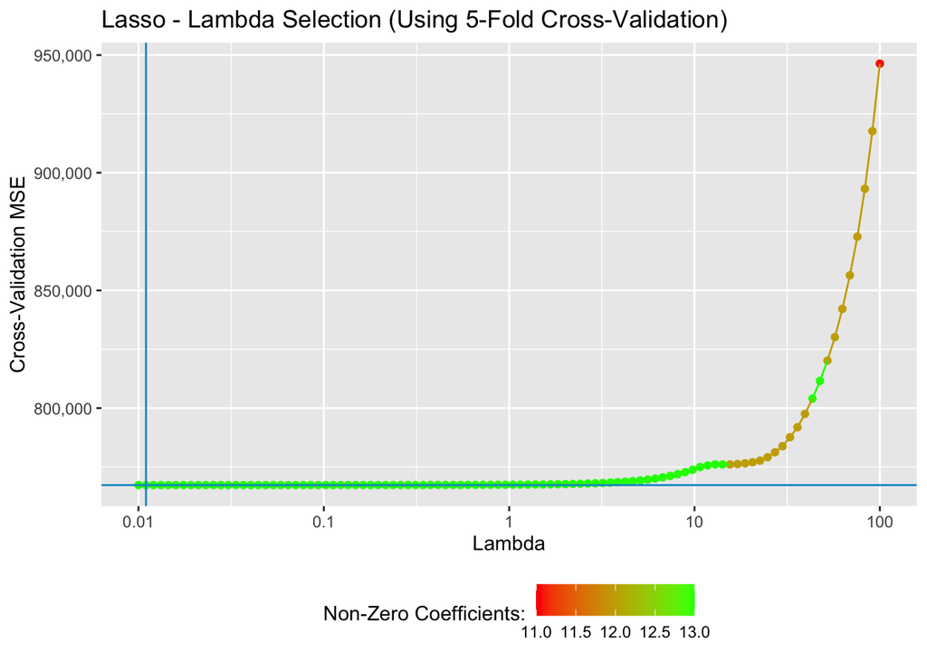

```r
train_mat <- dummyVars(Outstate ~ instate+Private+no.acprf+enrollper+add.cost+Elite+no.inprf+S.F.Ratio+  PhD + allsalary + Grad.Rate, data = College.train, fullRank = F) %>%
  predict(newdata = College.train) %>%
  as.matrix()

test_mat <- dummyVars(Outstate ~ instate+Private+no.acprf+enrollper+add.cost+Elite+no.inprf+S.F.Ratio+PhD + allsalary + Grad.Rate, data = College.test, fullRank = F) %>%
  predict(newdata = College.test) %>%
  as.matrix()
model_lasso <- cv.glmnet(y = College.train$Outstate,
                         x = train_mat,
                         alpha = 1,
                         lambda = 10^seq(2, -2, length = 100),
                         standardize = TRUE,
                         nfolds = 5,
                         thresh = 1e-12)

data.frame(lambda = model_lasso$lambda,
           cv_mse = model_lasso$cvm,
           nonzero_coeff = model_lasso$nzero) %>%
  ggplot(aes(x = lambda, y = cv_mse, col = nonzero_coeff)) +
  geom_point() +
  geom_line() +
  geom_vline(xintercept = model_lasso$lambda.min, col = "deepskyblue3") +
  geom_hline(yintercept = min(model_lasso$cvm), col = "deepskyblue3") +
  scale_x_continuous(trans = 'log10', breaks = c(0.01, 0.1, 1, 10, 100), labels = c(0.01, 0.1, 1, 10, 100)) +
  scale_y_continuous(labels = scales::comma_format()) +
  theme(legend.position = "bottom") +
  scale_color_gradient(low = "red", high = "green") +
  labs(x = "Lambda",
       y = "Cross-Validation MSE",
       col = "Non-Zero Coefficients:",
       title = "Lasso - Lambda Selection (Using 5-Fold Cross-Validation)")
```

```r
model_lasso_best <- glmnet(y = College.train$Outstate,
                           x = train_mat,
                           alpha = 1,
                           lambda = 10^seq(2,-5, length = 100))

lasso_pred <- predict(model_lasso_best, s = model_lasso$lambda.min, newx = test_mat)
(err.lasso <- mean((lasso_pred - College.test$Outstate)^2))
```

```
## [1] 611008.6
```

```r
lasso.coef = predict(model_lasso_best, s=model_lasso$lambda.min, type="coefficients")
lasso.coef
```

```
## 14 x 1 sparse Matrix of class "dgCMatrix"
##                         1
## (Intercept)  1.776302e+03
## instate      9.235862e-01
## Private.1    3.433884e+03
## Private.2   -4.448237e-09
## no.acprf     5.012625e+00
## enrollper   -1.354678e+01
## add.cost     3.296257e-01
## Elite.No    -3.802221e+02
## Elite.Yes    4.563947e-09
## no.inprf    -7.149875e+00
## S.F.Ratio   -2.405541e+01
## PhD          7.038409e+00
## allsalary   -7.799672e-01
## Grad.Rate    4.397255e+00
```

```r
par(mfrow=c(3,4))
require(gam)
```

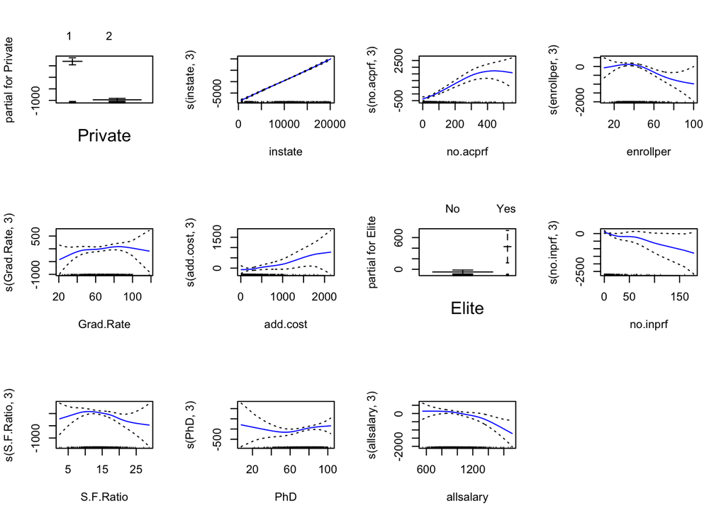

```r
gam.fit <- gam(Outstate ~
                 Private +   # categorical variable
                 s(instate,3) + s(no.acprf,3) + s(enrollper,3) +
                 s(Grad.Rate,3) + s(add.cost,3) + Elite + s(no.inprf,3) +  s(S.F.Ratio,3) + s(PhD,3) +s(allsalary,3) ,
                 data=College.train)
plot(gam.fit, se=TRUE, col="blue")
```

```r
gam_pred <- predict(gam.fit, College.test)
(err.gam <- mean((College.test$Outstate - gam_pred)^2))
```

```
## [1] 567968.9
```

```r
summary(gam.fit)
```

```
##
## Call: gam(formula = Outstate ~ Private + s(instate, 3) + s(no.acprf,
##     3) + s(enrollper, 3) + s(Grad.Rate, 3) + s(add.cost, 3) +
##     Elite + s(no.inprf, 3) + s(S.F.Ratio, 3) + s(PhD, 3) + s(allsalary,
##     3), data = College.train)
## Deviance Residuals:
##      Min       1Q   Median       3Q      Max
## -3240.24  -260.31   -12.03   215.84  4638.21
##
## (Dispersion Parameter for gaussian family taken to be 675749.7)
##
##     Null Deviance: 7293115283 on 410 degrees of freedom
## Residual Deviance: 257460588 on 381 degrees of freedom
## AIC: 6714.307
##
## Number of Local Scoring Iterations: NA
##
## Anova for Parametric Effects
##                  Df     Sum Sq    Mean Sq   F value    Pr(>F)
## Private           1 2734999164 2734999164 4047.3556 < 2.2e-16 ***
## s(instate, 3)     1 4186117794 4186117794 6194.7761 < 2.2e-16 ***
## s(no.acprf, 3)    1   45937611   45937611   67.9802 2.703e-15 ***
## s(enrollper, 3)   1    9737981    9737981   14.4106 0.0001709 ***
## s(Grad.Rate, 3)   1    2312255    2312255    3.4218 0.0651164 .
## s(add.cost, 3)    1    4935911    4935911    7.3043 0.0071866 **
## Elite             1    5092595    5092595    7.5362 0.0063335 **
## s(no.inprf, 3)    1    4275385    4275385    6.3269 0.0123028 *
## s(S.F.Ratio, 3)   1    1966148    1966148    2.9096 0.0888698 .
## s(PhD, 3)         1     350265     350265    0.5183 0.4719938
## s(allsalary, 3)   1    3698302    3698302    5.4729 0.0198296 *
## Residuals       381  257460588     675750
## ---
## Signif. codes:  0 '***' 0.001 '**' 0.01 '*' 0.05 '.' 0.1 ' ' 1
##
## Anova for Nonparametric Effects
##                 Npar Df Npar F   Pr(F)
## (Intercept)
## Private
## s(instate, 3)         2 2.3076 0.10088
## s(no.acprf, 3)        2 3.9453 0.02014 *
## s(enrollper, 3)       2 4.7957 0.00877 **
## s(Grad.Rate, 3)       2 1.5520 0.21317
## s(add.cost, 3)        2 0.9420 0.39076
## Elite
## s(no.inprf, 3)        2 1.7537 0.17454
## s(S.F.Ratio, 3)       2 2.7693 0.06397 .
## s(PhD, 3)             2 1.6526 0.19292
## s(allsalary, 3)       2 3.0149 0.05022 .
## ---
## Signif. codes:  0 '***' 0.001 '**' 0.01 '*' 0.05 '.' 0.1 ' ' 1
```

```r
require(glmnet)
xmat.train <- model.matrix(Outstate ~ ., data=new_train)[,-1]
xmat.test <- model.matrix(Outstate ~ ., data=new_test)[,-1]
fit.ridge <- cv.glmnet(xmat.train, new_train$Outstate, alpha=0)
(lambda <- fit.ridge$lambda.min)  # optimal lambda
```

```
## [1] 395.2071
```

```r
pred.ridge <- predict(fit.ridge, s=lambda, newx=xmat.test)
(err.ridge <- mean((new_test$Outstate - pred.ridge)^2))
```

```
## [1] 1185613
```

```r
coef.ridge <- predict(fit.ridge, type="coefficients", s=lambda)[1:11,]
coef.ridge[coef.ridge != 0]
```

```
##   (Intercept)       instate      no.acprf     enrollper      add.cost
## 3369.45410810    0.55584573    1.58408446  -24.32872202    0.02188264
##      no.inprf     S.F.Ratio           PhD     allsalary     Grad.Rate
##   -3.23288233  -83.29387435   21.58514482    1.96471634   11.94157893
##      EliteYes
##  652.03540935
```

```r
require(pls)
```

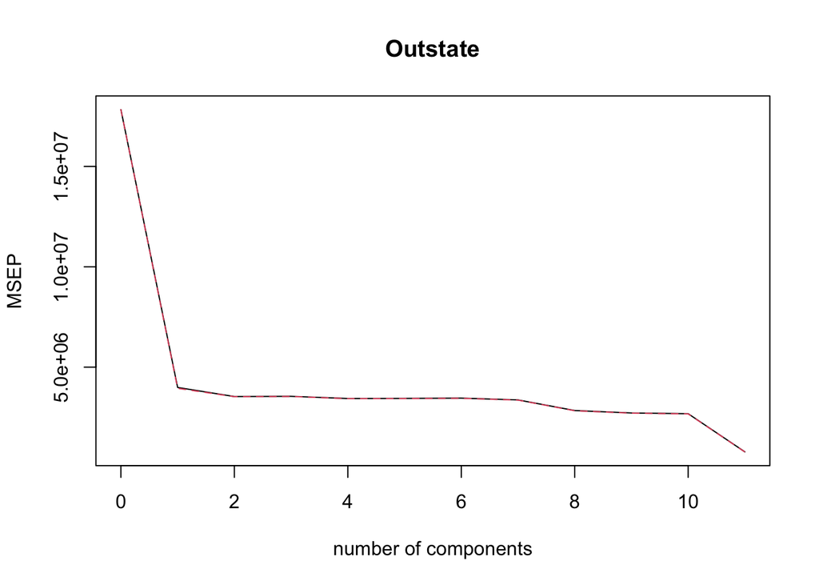

```r
set.seed(1)

fit.pcr <- pcr(Outstate~., data=new_train, scale=TRUE, validation="CV")
validationplot(fit.pcr, val.type="MSEP")
```

```r
summary(fit.pcr)
```

```
## Data:    X dimension: 411 11
##  Y dimension: 411 1
## Fit method: svdpc
## Number of components considered: 11
##
## VALIDATION: RMSEP
## Cross-validated using 10 random segments.
##        (Intercept)  1 comps  2 comps  3 comps  4 comps  5 comps  6 comps
## CV            4223     1997     1880     1883     1854     1856     1859
## adjCV         4223     1986     1879     1881     1852     1853     1857
##        7 comps  8 comps  9 comps  10 comps  11 comps
## CV        1835     1685     1648      1637     882.5
## adjCV     1833     1682     1646      1634     879.9
##
## TRAINING: % variance explained
##           1 comps  2 comps  3 comps  4 comps  5 comps  6 comps  7 comps
## X           31.18    55.74    65.73    73.61    80.42    86.15    91.00
## Outstate    77.92    80.57    80.65    81.44    81.55    81.60    82.29
##           8 comps  9 comps  10 comps  11 comps
## X           94.45    97.39     99.29    100.00
## Outstate    85.02    85.65     86.05     96.07
```

```r
pred.pcr <- predict(fit.pcr, new_test, ncomp=11)  # min Cv at M=16
(err.pcr <- mean((new_test$Outstate - pred.pcr)^2))
```

```
## [1] 611012.6
```

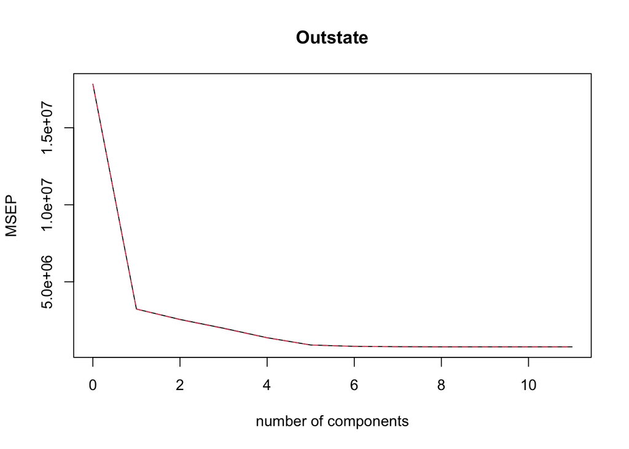

```r
require(pls)
set.seed(1)
fit.pls <- plsr(Outstate~., data=new_train, scale=TRUE, validation="CV")
validationplot(fit.pls, val.type="MSEP")
```

```r
summary(fit.pls)
```

```
## Data:    X dimension: 411 11
##  Y dimension: 411 1
## Fit method: kernelpls
## Number of components considered: 11
##
## VALIDATION: RMSEP
## Cross-validated using 10 random segments.
##        (Intercept)  1 comps  2 comps  3 comps  4 comps  5 comps  6 comps
## CV            4223     1798     1599     1409     1171    947.7    899.4
## adjCV         4223     1796     1594     1403     1166    944.8    897.1
##        7 comps  8 comps  9 comps  10 comps  11 comps
## CV       887.2    882.8    882.6     882.5     882.5
## adjCV    884.4    880.2    880.1     880.0     879.9
##
## TRAINING: % variance explained
##           1 comps  2 comps  3 comps  4 comps  5 comps  6 comps  7 comps
## X            31.0    45.33    60.12    65.96    70.04    77.15    82.27
## Outstate     82.3    86.76    90.00    93.01    95.44    95.95    96.05
##           8 comps  9 comps  10 comps  11 comps
## X           86.19    91.18     95.07    100.00
## Outstate    96.07    96.07     96.07     96.07
```

```r
pred.pls <- predict(fit.pls, new_test, ncomp=10)  # min Cv at M=10
(err.pls <- mean((new_test$Outstate - pred.pls)^2))
```

```
## [1] 610951.8
```

```r
library(tree)
df.tree = tree(Outstate~., data=new_train)
summary(df.tree)
```

```
##
## Regression tree:
## tree(formula = Outstate ~ ., data = new_train)
## Variables actually used in tree construction:
## [1] "instate"  "no.acprf"
## Number of terminal nodes:  8
## Residual mean deviance:  1045000 = 421100000 / 403
## Distribution of residuals:
##     Min.  1st Qu.   Median     Mean  3rd Qu.     Max.
## -3371.00  -591.10     6.97     0.00   598.70  5394.00
```

```r
df.tree
```

```
## node), split, n, deviance, yval
##       * denotes terminal node
##
##  1) root 411 7.293e+09 10760
##    2) instate < 12102.5 279 1.564e+09  8378
##      4) instate < 8665 163 5.935e+08  6891
##        8) instate < 2803 92 1.538e+08  5951 *
##        9) instate > 2803 71 2.533e+08  8109
##         18) no.acprf < 131.5 55 6.413e+07  7460 *
##         19) no.acprf > 131.5 16 8.650e+07 10340 *
##      5) instate > 8665 116 1.035e+08 10470
##       10) instate < 10327.5 50 9.941e+06  9522 *
##       11) instate > 10327.5 66 1.513e+07 11180 *
##    3) instate > 12102.5 132 7.971e+08 15800
##      6) instate < 15815.5 65 6.923e+07 13590 *
##      7) instate > 15815.5 67 1.019e+08 17940
##       14) instate < 17806.5 30 9.049e+06 16730 *
##       15) instate > 17806.5 37 1.336e+07 18920 *
```

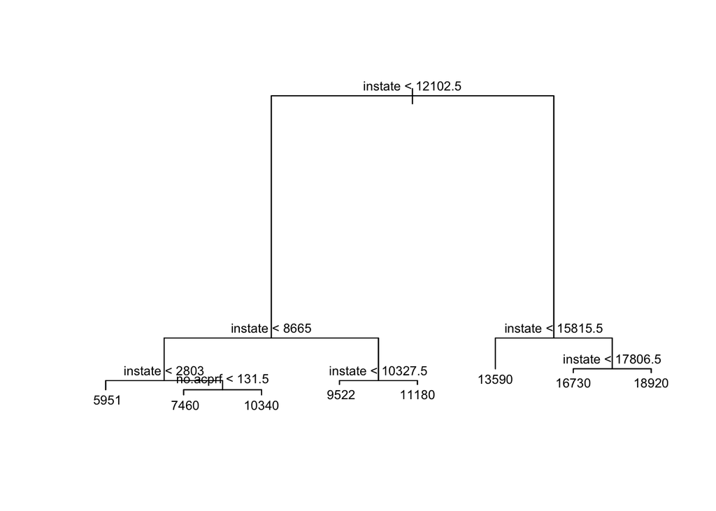

```r
plot(df.tree)
text(df.tree, pretty=0,cex=.75)
```

```r
tree.pred = predict(df.tree, new_test)
err.tree <- mean((new_test$Outstate - tree.pred)^2)
err.tree
```

```
## [1] 1177070
```

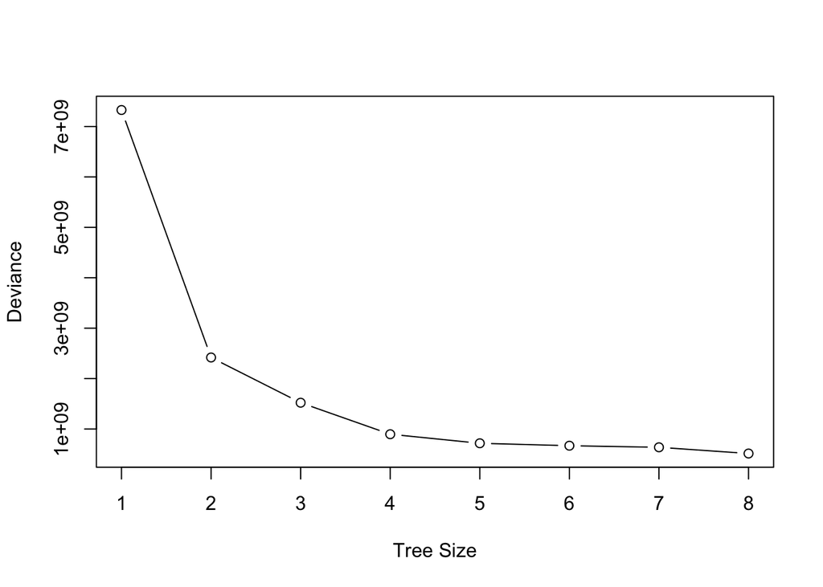

```r
cv.df = cv.tree(df.tree, FUN=prune.tree)
plot(cv.df$size, cv.df$dev, type="b", xlab="Tree Size", ylab="Deviance")
```

```r
df.pruned = prune.tree(df.tree, best=8)
summary(df.pruned)
```

```
##
## Regression tree:
## tree(formula = Outstate ~ ., data = new_train)
## Variables actually used in tree construction:
## [1] "instate"  "no.acprf"
## Number of terminal nodes:  8
## Residual mean deviance:  1045000 = 421100000 / 403
## Distribution of residuals:
##     Min.  1st Qu.   Median     Mean  3rd Qu.     Max.
## -3371.00  -591.10     6.97     0.00   598.70  5394.00
```

```r
pred.pruned = predict(df.pruned, new_test)
err.tree.p <- mean((new_test$Outstate - pred.pruned)^2)
err.tree.p
```

```
## [1] 1177070
```

```r
fit.cubist <- train(Outstate~ ., data = new_train, method = "cubist")

cubist_pred <- predict(fit.cubist,new_test)

err.cubist<- mean((new_test$Outstate - cubist_pred)^2)
err.cubist
```

```
## [1] 156728.6
```

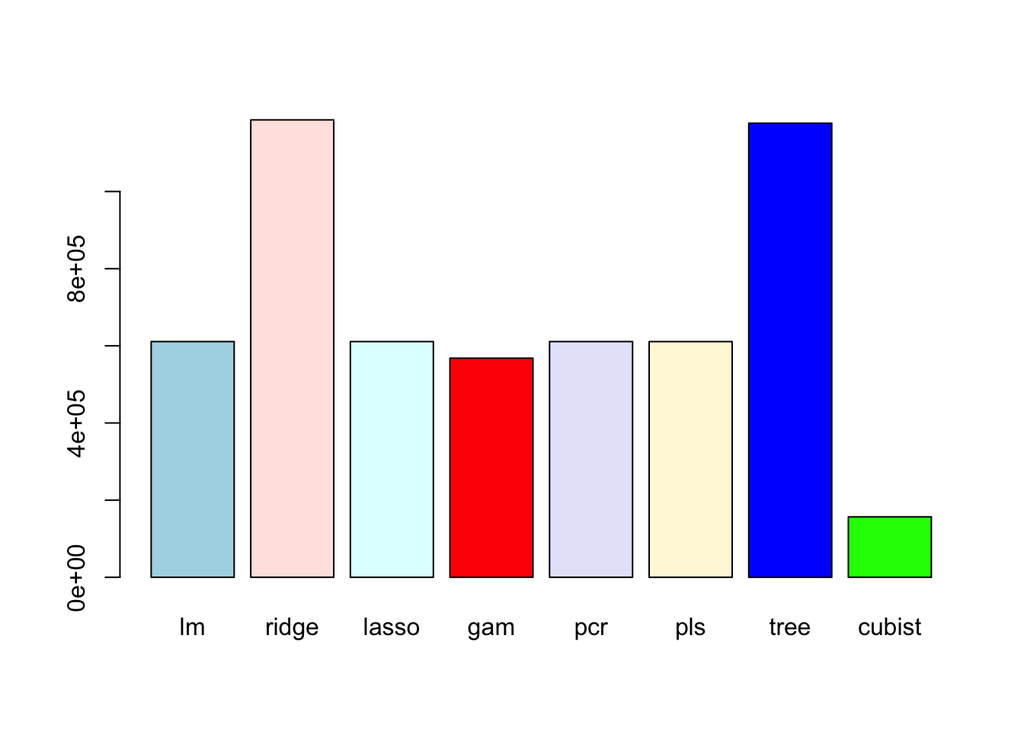

```r
err.all <- c(lm.err, err.ridge, err.lasso,err.gam, err.pcr, err.pls,err.tree,err.cubist)
names(err.all) <- c("lm", "ridge", "lasso", "gam", "pcr", "pls", 'tree',"cubist")
barplot(err.all, col = c("lightblue", "mistyrose", "lightcyan","red","lavender", "cornsilk", 'blue', "green"))
```

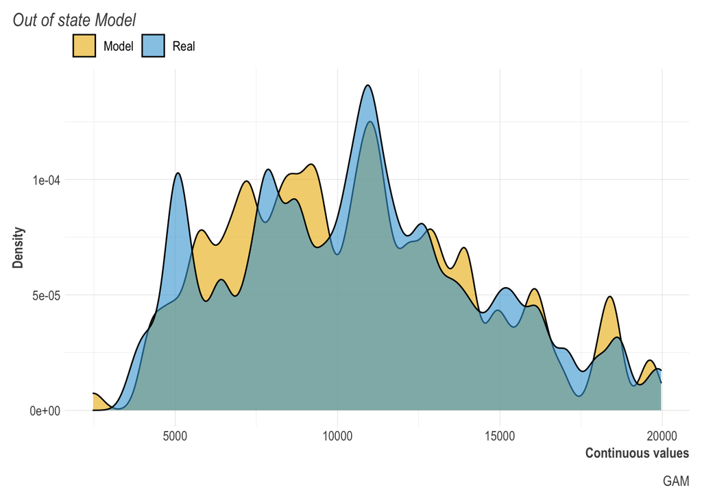

```r
lares::mplot_density(tag = College.test$Outstate,
                     score = gam_pred,
                     subtitle = "Out of state Model",
                     model_name = "GAM")
```

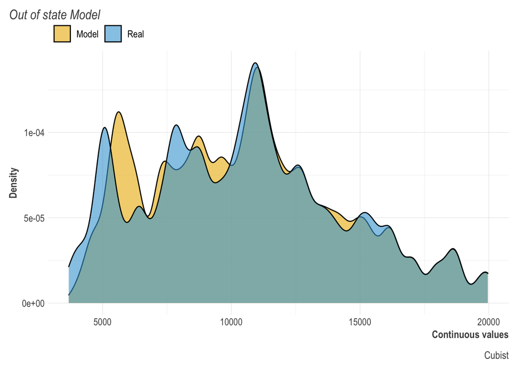

```r
lares::mplot_density(tag = new_test$Outstate,
                     score = cubist_pred,
                     subtitle = "Out of state Model",
                     model_name = "Cubist")
```

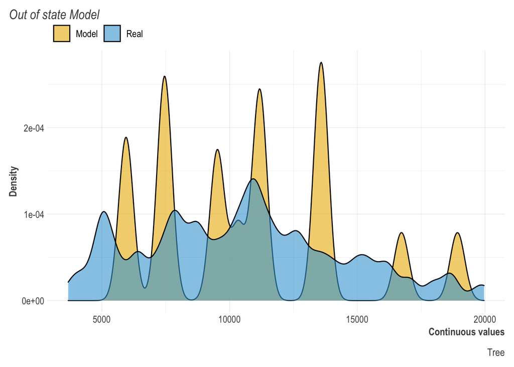

```r
lares::mplot_density(tag = new_test$Outstate,
                     score = pred.pruned,
                     subtitle = "Out of state Model",
                     model_name = "Tree")
```

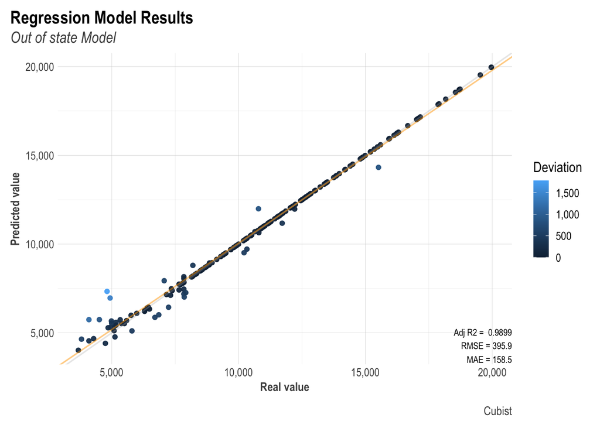

```r
lares::mplot_lineal(tag = new_test$Outstate,
                     score = cubist_pred,
                     subtitle = "Out of state Model",
                     model_name = "Cubist")
```